# Plots: interactions, contrasts, and slopes

Note: This vignette requires version 0.7.2 of `marginaleffects`, or [the development version.](https://vincentarelbundock.github.io/marginaleffects/#installation)

The `marginaleffects` package includes several flexible functions to plot estimates and to display interactions:

- `plot()`: Plot the raw output of `marginaleffects()` or `comparisons()`
- Interaction / conditional / heterogenous:
  - `plot_cap`: Conditional Adjusted Predictions (equivalent to `predictions()`)
  - `plot_cco`: Conditional Contrasts (equivalent to `comparisons()`)
  - `plot_cme`: Conditional Marginal Effects (equivalent to `marginaleffects()`)

The “interaction” function are designed to display how the outcome or how the effect of a predictor changes with respect to another variable.

This vignette focuses on `plot_cap()`, but the same ideas apply to `plot_cme()` and `plot_cco()` as well. In the examples below, we will use the `patchwork` package to combine plots and the `ggplot2` package to customize their content and appearance:

```r
library(marginaleffects)
library(patchwork)
library(ggplot2)
```

# Interactions: Conditional Adjusted Predictions

Consider a linear model with interactions, where the relationship between `hp` and `mpg` is conditional on the values of `wt` and `cyl`:

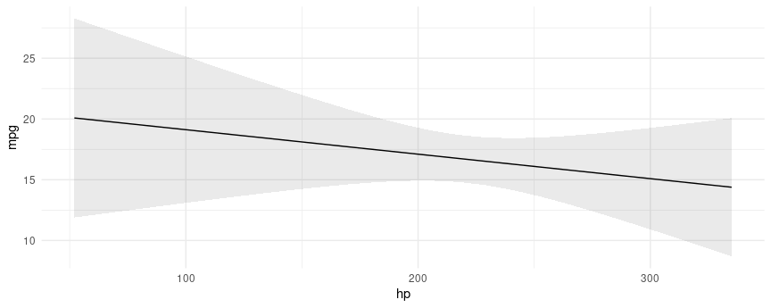

```r
mod <- lm(mpg ~ hp * wt * factor(cyl), data = mtcars)

plot_cap(mod, condition = "hp")
```

We can show the predicted values of `mpg` for different values of different predictors:

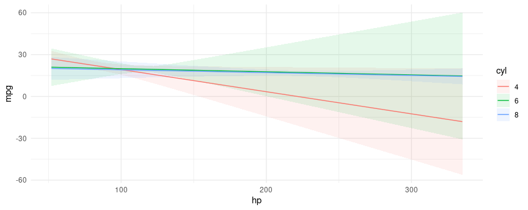

```r
plot_cap(mod, condition = c("hp", "cyl"))
```

We can include a 3rd conditioning variable, specify what values we want to consider, and use one of several string shortcuts for common reference values (“threenum”, “minmax”, “quartile”, etc.):

[figure not shown]

```r
plot_cap(mod, condition = list(hp = 110:120, "wt" = "threenum")) /

plot_cap(mod, condition = list("hp", "wt" = "minmax")) /

plot_cap(mod, condition = list("hp", "wt" = fivenum))
```

# Customizing plots

A very useful feature of the plotting functions in this package is that they produce normal `ggplot2` objects. So we can customize them to our heart’s content, using `ggplot2` itself, or one of the many packages designed to augment its functionalities:

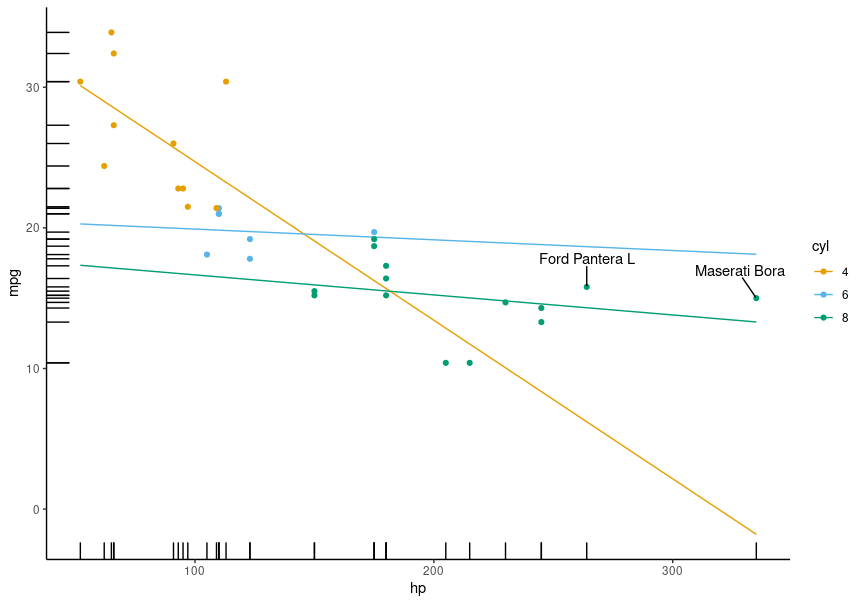

```r
library(ggokabeito)
library(ggrepel)

mt <- mtcars
mt$label <- row.names(mt)

mod <- lm(mpg ~ hp * factor(cyl), data = mt)

plot_cap(mod, condition = c("hp", "cyl"), vcov = FALSE) +
    geom_point(aes(x = hp, y = mpg, color = factor(cyl)), data = mt) +
    geom_rug(aes(x = hp, y = mpg), data = mt) +
    geom_text_repel(aes(x = hp, y = mpg, label = label),
                    data = subset(mt, hp > 250),
                    nudge_y = 2) +
    theme_classic() +
    scale_color_okabe_ito()
```

All the plotting functions work with all the model supported by the `marginaleffects` package, so we can plot the output of a logistic regression model. This plot shows the probability of survival aboard the Titanic, for different ages and different ticket classes:

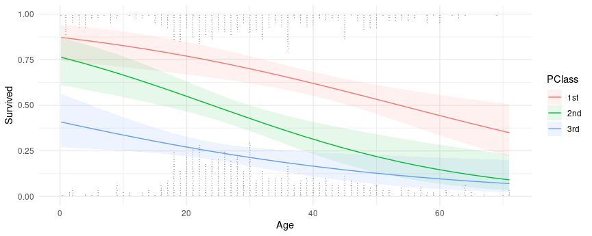

```r
library(ggdist)

dat <- "https://vincentarelbundock.github.io/Rdatasets/csv/Stat2Data/Titanic.csv"
dat <- read.csv(dat)

mod <- glm(Survived ~ Age * PClass, data = dat, family = binomial)

plot_cap(mod, condition = c("Age", "PClass")) +
    geom_dots(
        alpha = .8,
        scale = .3,
        pch = 18,
        data = dat, aes(
        x = Age,
        y = Survived,
        side = ifelse(Survived == 1, "bottom", "top")))
```

Thanks to [Andrew Heiss](https://bayesf22-notebook.classes.andrewheiss.com/bayes-rules/13-chapter.html) who inspired this plot.

# Fits and smooths

We can compare the model predictors with fits and smoothers using the `geom_smooth()` function from the `ggplot2` package:

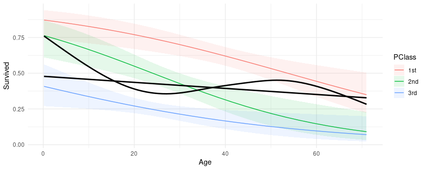

```r
dat <- "https://vincentarelbundock.github.io/Rdatasets/csv/Stat2Data/Titanic.csv"
dat <- read.csv(dat)
mod <- glm(Survived ~ Age * PClass, data = dat, family = binomial)

plot_cap(mod, condition = c("Age", "PClass")) +
    geom_smooth(data = dat, aes(Age, Survived), method = "lm", se = FALSE, color = "black") +
    geom_smooth(data = dat, aes(Age, Survived), se = FALSE, color = "black")
```